# ETC1010 Assignment 3

ETC1010

23/04/2018

```r
library(tidyverse)
library(readr)
Melbourne_housing_FULL <- read_csv("data/Melbourne_housing_FULL.csv")
housing_filtered_missing <- Melbourne_housing_FULL %>%
  select(Price, Rooms, Type, Distance, Bedroom2, Bathroom)
```

# MISSING VALUES SUMMARY

```r
library(naniar)
miss_summary(housing_filtered_missing)
```

```
## # A tibble: 1 x 7
##   miss_df_prop miss_var_prop miss_case_prop miss_case_table miss_var_table
##          <dbl>         <dbl>          <dbl> <list>          <list>
## 1        0.115         0.667          0.403 <tibble [4 × 3… <tibble [5 × …
## # ... with 2 more variables: miss_var_summary <list>,
## #   miss_case_summary <list>
```

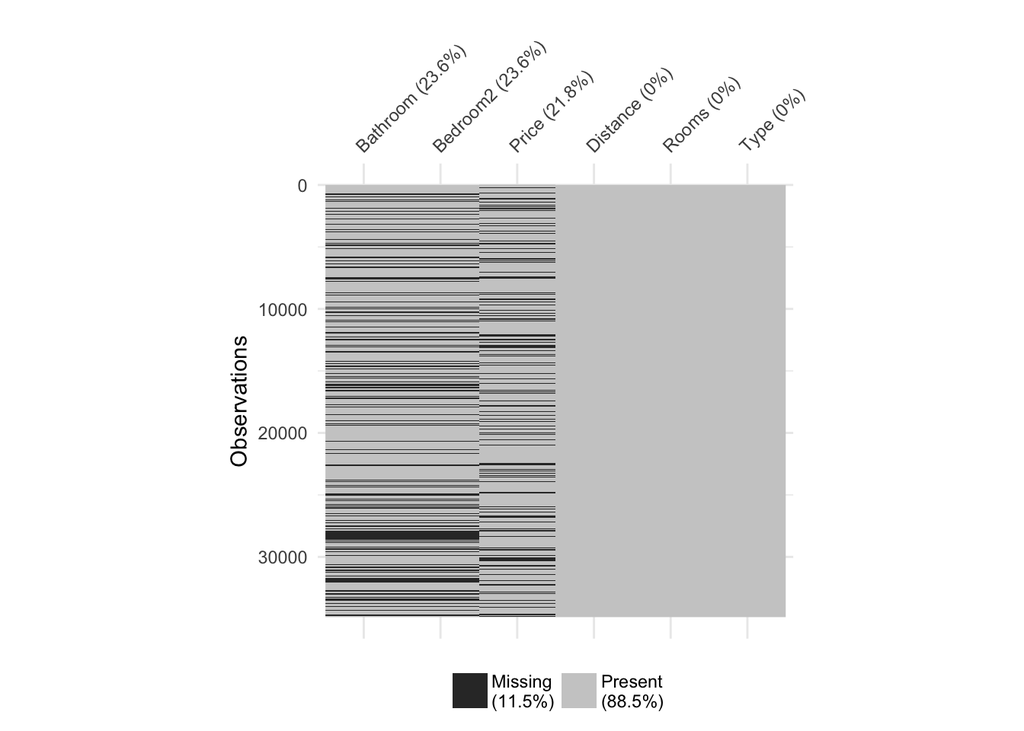

```r
vis_miss(housing_filtered_missing, sort_miss=TRUE) + theme(aspect.ratio=1)
```

# CODE FOR THE STRATEGY TO DEAL WITH MISSING VALUES

```r
housing_filtered <- housing_filtered_missing %>%
  filter(!is.na(Price)) %>%
  filter(!is.na(Bedroom2)) %>%
  filter(!is.na(Bathroom))
```

# PLOT FOR RELATIONSHIP BETWEEN PRICE AND ROOMS

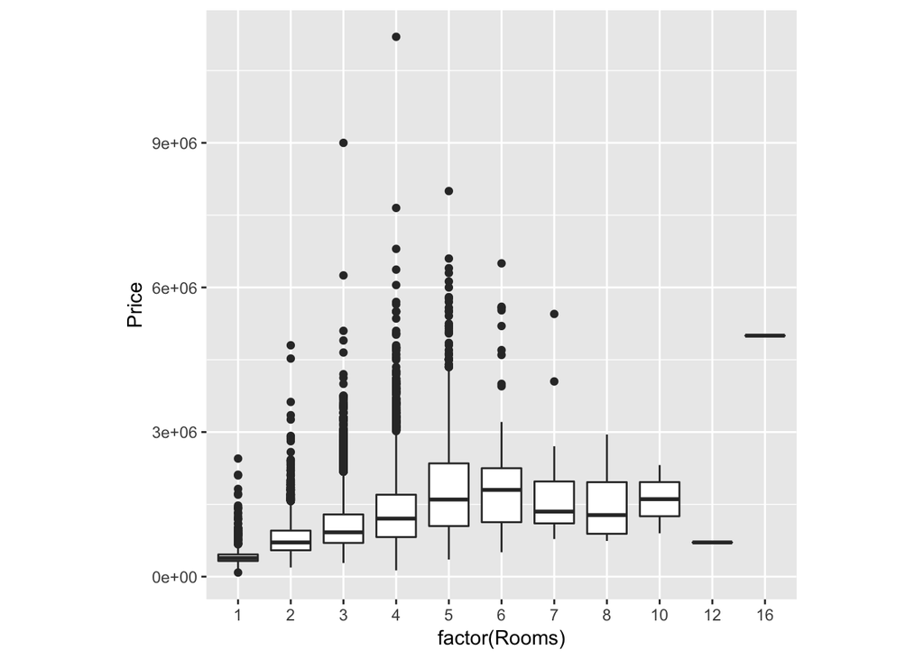

```r
ggplot(housing_filtered, aes(x=factor(Rooms), y=Price)) + geom_boxplot() +
  geom_smooth(method="lm", se=FALSE) + theme(aspect.ratio=1)
```

# PLOT FOR RELATIONSHIP BETWEEN LOG_PRICE AND ROOMS<8

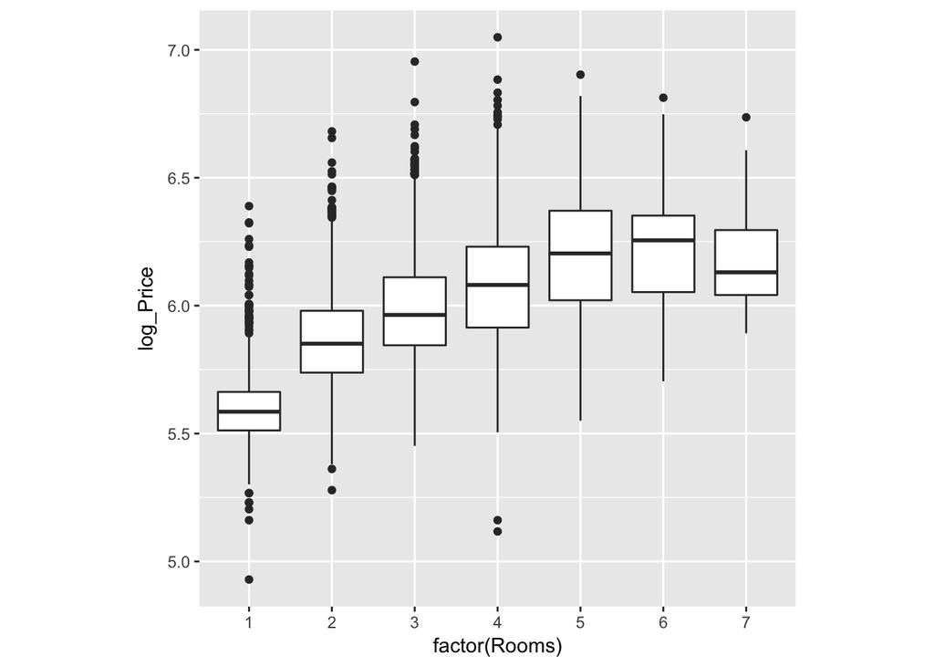

```r
house_1 <- housing_filtered %>%
  filter(Rooms < 8)
house_2 <- house_1 %>%
  mutate(log_Price = log10(Price))

ggplot(house_2, aes(x=factor(Rooms), y=log_Price)) + geom_boxplot() +
  geom_smooth(method="lm", se=FALSE) + theme(aspect.ratio=1)
```

# MODEL OF PRICE AND ROOMS

```r
house_lm <- lm(Price ~ Rooms, data=housing_filtered)
library(broom)
glance(house_lm)
```

```
##   r.squared adj.r.squared    sigma statistic p.value df  logLik    AIC
## 1 0.1978825     0.1978439 584501.2  5130.869       0  2 -305706 611418
##        BIC     deviance df.residual
## 1 611441.9 7.105463e+15       20798
```

# MODEL OF LOG_PRICE AND ROOMS<8

```r
house_lm <- lm(log_Price ~ Rooms, data=house_2)
glance(house_lm)
```

```
##   r.squared adj.r.squared    sigma statistic p.value df  logLik      AIC
## 1  0.252042      0.252006 0.193947  7002.984       0  2 4599.08 -9192.16
##         BIC deviance df.residual
## 1 -9168.334 781.7242       20782
```

It is plausible that number of rooms would have an effect on the housing price as more rooms generally mean a larger building and area of land.

The R squared value of this model indicates that about 25% of the variation in the log of price is explained by the variable rooms when restricted to observations with less than 8 rooms. This is quite low so the model can be improved.

# PLOT FOR RELATIONSHIP BETWEEN LOG_PRICE AND TYPE

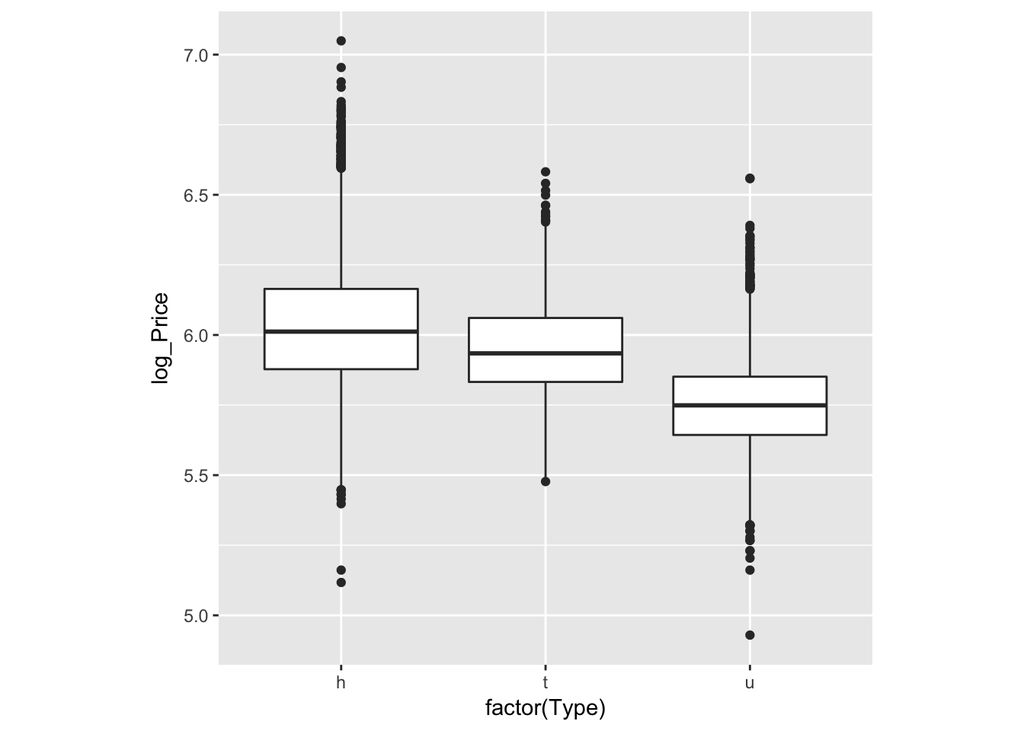

```r
ggplot(house_2, aes(x=factor(Type), y=log_Price)) + geom_boxplot() +
  geom_smooth(method="lm", se=FALSE) + theme(aspect.ratio=1)
```

There are no extreme outliers or any evidence of a skewed distribution, so no filtering of range of transformations are required for these variables. The plot shows that houses have the highest log of price, followed by townhouses and units respectively. The plot also shows that the IQR of these 3 housing types are relatively the same and that townhouses have the lowest range in log of price.

# MODEL OF LOG_PRICE, ROOMS<8 AND TYPE

```r
house_lm <- lm(log_Price ~ Rooms + Type, data=house_2)
glance(house_lm)
```

```
##   r.squared adj.r.squared     sigma statistic p.value df   logLik
## 1 0.3046541     0.3045538 0.1870104  3034.803       0  4 5357.046
##         AIC       BIC deviance df.residual
## 1 -10704.09 -10664.38  726.737       20780
```

It is plausible that the type of housing would have an effect on the housing price as units and townhouses are generally smaller than houses both in terms of indoor and outdoor space.

The R squared and adjusted R squared of this model are greater than the previous model by about 5% indicating that the addition of the Type variable to the model increases its goodness of fit and can explain a larger proportion of the variation in the log of price, where the model can explain about 30% of variation. This model also has a lower deviance which reinforces that it is a better model than the previous one.

# PLOT OF RELATIONSHIP BETWEEN LOG_PRICE AND DISTANCE

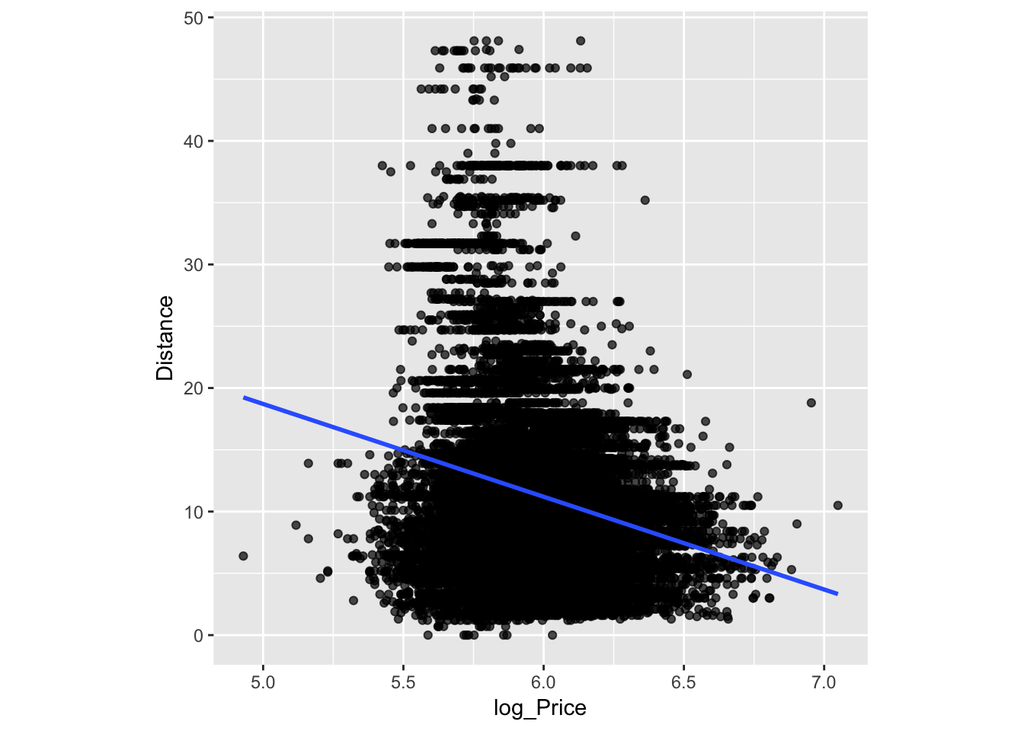

```r
ggplot(house_2, aes(x=log_Price, y=Distance)) + geom_point(alpha=0.7) +
  geom_smooth(method="lm", se=FALSE) + theme(aspect.ratio=1)
```

The plot shows that there is a negative relationship between distance and the log of price, indicating that as distance from the CBD decreases, the log of price increases. This is plausible as housing prices are generally more expensive the closer the building is to the CBD because there is more competition for buildings and land that is closest to the CBD.

# MODEL OF LOG_PRICE, ROOMS<8, TYPE AND DISTANCE

```r
house_lm <- lm(log_Price ~ Rooms + Type + Distance, data=house_2)
glance(house_lm)
```

```
##   r.squared adj.r.squared     sigma statistic p.value df   logLik
## 1  0.489386     0.4892877 0.1602589  4978.785       0  5 8566.047
##         AIC       BIC deviance df.residual
## 1 -17120.09 -17072.44 533.6655       20779
```

The R squared and adjusted R squared of this model are greater than the previous model by about 19% indicating that the addition of the Distance variable to the model increases its goodness of fit and can explain a larger proportion of the variation in the log of price, where the model can explain about 49% of variation. This model also has a lower deviance which reinforces that it is a better model than the previous one.